# Report: Insight Data

#### By : Dayron Tula

## Introduction

The data we find in the real world is often messy and unreadable. The process to clean the data is lengthy and it could also be costly. The data analyzed in this project is from a Twitter account called WeRateDogs. This account rate dogs based comments:

#### For example:

[figure not shown]

This is a comment with a picture of a dog along with a rating score of 13/10.

Going into this project I decided that I wanted to learn more about the type of breeds that are considered to be the highest rated according to Twitter comments. To do this, I've used several Twitter data to help me through the process; however, the data that I used didn't come clean in order to fully understand it.

#### For example:

Below is a picture of a dog in a shopping cart, but the data I pulled recognized the image as a shopping cart and another image is of a chicken and not a dog.

[figure not shown]

[figure not shown]

Due to these issues, I removed many tweets that the image predicition did not give a dog breed result. In addition, I also removed duplicate tweet images. The purpose of doing this is to provide a more clear result on what breed of dogs is the most popular.

## Visuals

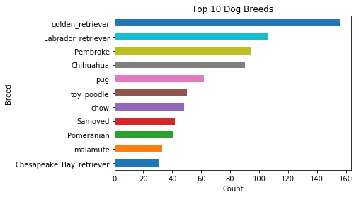

The golden retriever breed seems to win popularity among twitter comments with the highest count of tweets. It is interesting to see how chihuahuas made it up in the list at number four most popular. As a Siberian Husky owner, it is strange not to see them made it to the list.

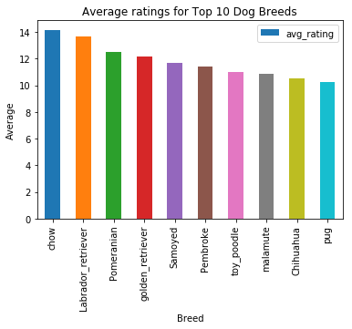

## Conclusion

Overall we can see that these type of dogs are most popular based on twitter comments; however, we cannot determine for sure the popularity of these dogs based on a single string of data pulled from twitter but it is interesting to know. These findings can also serve as a foundation to other data from other sources.

For example, we can also pull data from google searches to see what breed of dogs are being searched most often.